# IS6400 Week 3 Tutorial: Data Exploration

This tutorial follows the original "Week 3 - Description" notebook, but is **aligned with the Week 3 assignment difficulty**. It covers:

- Data types (nominal, ordinal, interval, ratio)
- Percentiles and grouped descriptive statistics
- Skewness and kurtosis
- Visualization (histogram, boxplot, scatter, parallel coordinates)
- Missing values: mean vs median vs KNN imputation
- Outlier detection: IQR vs Z-score
- Standardization: StandardScaler vs RobustScaler
- Covariance, correlation, and correlation-vs-causation

**How to use:** Run each cell one by one (Shift+Enter). Read the markdown explanations carefully; the same techniques are required in the assignment.

## 1. Load the Iris Data

The Iris dataset contains 150 flowers from three species.  
Each row is an **object** (record, sample, instance).  
Each column is an **attribute** (variable, feature).

```python
import pandas as pd
import numpy as np
import matplotlib.pyplot as plt
import seaborn as sns

from sklearn.impute import SimpleImputer, KNNImputer
from sklearn.preprocessing import StandardScaler, RobustScaler

np.random.seed(42)
plt.rcParams['figure.figsize'] = (9, 5)
plt.rcParams['axes.grid'] = True
sns.set_style('whitegrid')

data = pd.read_csv('iris.txt', header=None)
data.columns = ['sepal length', 'sepal width', 'petal length', 'petal width', 'class']
data.head(10)
```

|  | sepal length | sepal width | petal length | petal width | class |
| --- | --- | --- | --- | --- | --- |
| 0 | 5.1 | 3.5 | 1.4 | 0.2 | Iris-setosa |
| 1 | 4.9 | 3.0 | 1.4 | 0.2 | Iris-setosa |
| 2 | 4.7 | 3.2 | 1.3 | 0.2 | Iris-setosa |
| 3 | 4.6 | 3.1 | 1.5 | 0.2 | Iris-setosa |
| 4 | 5.0 | 3.6 | 1.4 | 0.2 | Iris-setosa |
| 5 | 5.4 | 3.9 | 1.7 | 0.4 | Iris-setosa |
| 6 | 4.6 | 3.4 | 1.4 | 0.3 | Iris-setosa |
| 7 | 5.0 | 3.4 | 1.5 | 0.2 | Iris-setosa |
| 8 | 4.4 | 2.9 | 1.4 | 0.2 | Iris-setosa |
| 9 | 4.9 | 3.1 | 1.5 | 0.1 | Iris-setosa |

## 2. Descriptive Statistics, Percentiles, Skewness and Kurtosis

For each numeric attribute we report:

- mean, median, mode
- std, min, max
- Q1, median, Q3, IQR
- skewness (symmetry), kurtosis (tailedness)

Percentiles are important in real data: the 90th percentile of prices is often more meaningful than the mean.

```python
def describe_col(df, col):
    s = df[col]
    q1, q3 = s.quantile(0.25), s.quantile(0.75)
    return pd.Series({
        'mean': s.mean(),
        'median': s.median(),
        'mode': s.mode().iloc[0],
        'std': s.std(),
        'min': s.min(),
        'max': s.max(),
        'Q1': q1,
        'Q3': q3,
        'range': s.max() - s.min(),
        'IQR': q3 - q1,
        'skew': s.skew(),
        'kurt': s.kurt()
    })

describe_col(data, 'sepal length')
```

```
mean      5.843333
median    5.800000
mode      5.000000
std       0.828066
min       4.300000
max       7.900000
Q1        5.100000
Q3        6.400000
range     3.600000
IQR       1.300000
skew      0.314911
kurt     -0.552064
dtype: float64
```

```python
# Full table for all numeric attributes
pd.DataFrame({col: describe_col(data, col) for col in
              ['sepal length', 'sepal width', 'petal length', 'petal width']}).T
```

|  | mean | median | mode | std | min | max | Q1 | Q3 | range | IQR | skew | kurt |
| --- | --- | --- | --- | --- | --- | --- | --- | --- | --- | --- | --- | --- |
| sepal length | 5.843333 | 5.80 | 5.0 | 0.828066 | 4.3 | 7.9 | 5.1 | 6.4 | 3.6 | 1.3 | 0.314911 | -0.552064 |
| sepal width | 3.054000 | 3.00 | 3.0 | 0.433594 | 2.0 | 4.4 | 2.8 | 3.3 | 2.4 | 0.5 | 0.334053 | 0.290781 |
| petal length | 3.758667 | 4.35 | 1.5 | 1.764420 | 1.0 | 6.9 | 1.6 | 5.1 | 5.9 | 3.5 | -0.274464 | -1.401921 |
| petal width | 1.198667 | 1.30 | 0.2 | 0.763161 | 0.1 | 2.5 | 0.3 | 1.8 | 2.4 | 1.5 | -0.104997 | -1.339754 |

```python
# Percentiles
percentiles = [0.25, 0.50, 0.75, 0.90, 0.95, 0.99]
data[['sepal length', 'sepal width', 'petal length', 'petal width']].quantile(percentiles)
```

|  | sepal length | sepal width | petal length | petal width |
| --- | --- | --- | --- | --- |
| 0.25 | 5.100 | 2.800 | 1.60 | 0.3 |
| 0.50 | 5.800 | 3.000 | 4.35 | 1.3 |
| 0.75 | 6.400 | 3.300 | 5.10 | 1.8 |
| 0.90 | 6.900 | 3.610 | 5.80 | 2.2 |
| 0.95 | 7.255 | 3.800 | 6.10 | 2.3 |
| 0.99 | 7.700 | 4.151 | 6.70 | 2.5 |

Skewness near 0 → symmetric.  
Positive skew → right tail longer than left tail.  
Kurtosis near 0 → similar to normal distribution tails; large positive → heavy tails.

## 3. Frequency Count and Grouped Statistics

For the `class` attribute we count how many flowers belong to each species.

Grouped statistics show whether the distribution of a variable differs across categories — this is one of the key steps in the assignment.

```python
print(data['class'].value_counts())
print()
print(data['class'].value_counts(normalize=True).round(3))
```

```
class
Iris-setosa        50
Iris-versicolor    50
Iris-virginica     50
Name: count, dtype: int64

class
Iris-setosa        0.333
Iris-versicolor    0.333
Iris-virginica     0.333
Name: proportion, dtype: float64
```

```python
# Grouped statistics: mean, median, std per species
data.groupby('class')[['sepal length', 'sepal width',
                       'petal length', 'petal width']].agg(['mean', 'median', 'std'])
```

| class | sepal length mean | sepal length median | sepal length std | sepal width mean | sepal width median | sepal width std | petal length mean | petal length median | petal length std | petal width mean | petal width median | petal width std |
| --- | --- | --- | --- | --- | --- | --- | --- | --- | --- | --- | --- | --- |
| Iris-setosa | 5.006 | 5.0 | 0.352490 | 3.418 | 3.4 | 0.381024 | 1.464 | 1.50 | 0.173511 | 0.244 | 0.2 | 0.107210 |
| Iris-versicolor | 5.936 | 5.9 | 0.516171 | 2.770 | 2.8 | 0.313798 | 4.260 | 4.35 | 0.469911 | 1.326 | 1.3 | 0.197753 |
| Iris-virginica | 6.588 | 6.5 | 0.635880 | 2.974 | 3.0 | 0.322497 | 5.552 | 5.55 | 0.551895 | 2.026 | 2.0 | 0.274650 |

**Insight:** petal length varies much more across species than sepal width.  
This kind of group-level view is essential when we later compare `log_price` across `city` or `property_type` in the assignment.

## 4. Data Visualization

### 4.1 Histogram

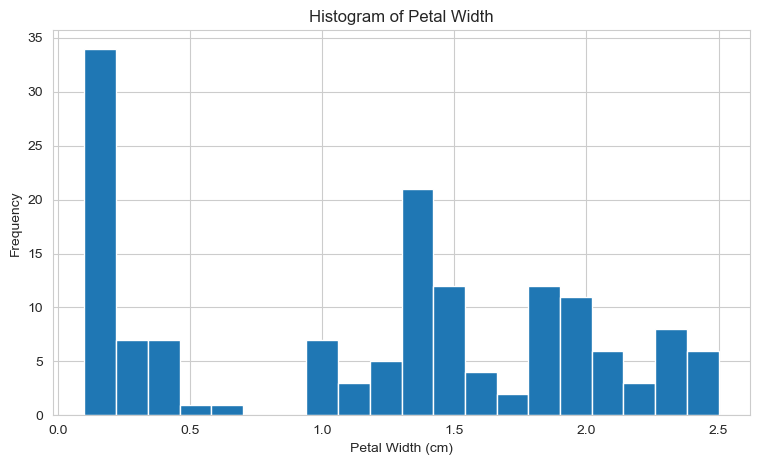

```python
data['petal width'].hist(bins=20)
plt.title('Histogram of Petal Width')
plt.xlabel('Petal Width (cm)')
plt.ylabel('Frequency')
plt.show()
```

Multiple peaks suggest the variable may be a mixture of several populations (here, three species). This is an important warning about distributional shape.

### 4.2 Boxplot

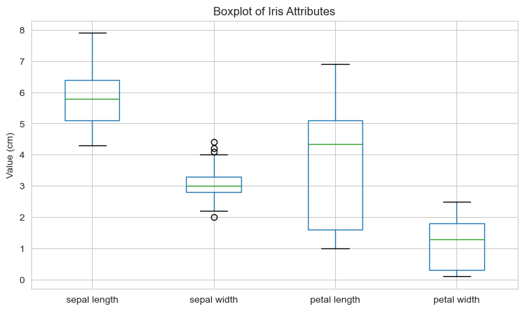

```python
data.boxplot()
plt.title('Boxplot of Iris Attributes')
plt.ylabel('Value (cm)')
plt.show()
```

Petal length and width have larger ranges than sepal width. No obvious extreme outliers — we will see what happens when we detect outliers with IQR and Z-score.

### 4.3 Scatter Plot

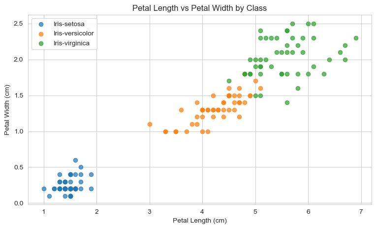

```python
for name, group in data.groupby('class'):
    plt.scatter(group['petal length'], group['petal width'],
                alpha=0.7, label=name)
plt.xlabel('Petal Length (cm)')
plt.ylabel('Petal Width (cm)')
plt.title('Petal Length vs Petal Width by Class')
plt.legend()
plt.show()
```

### 4.4 Parallel Coordinates

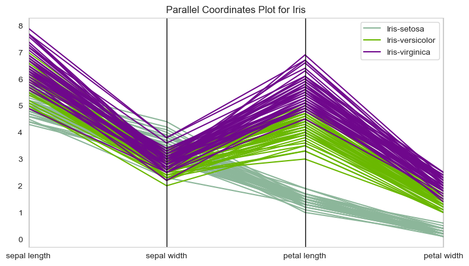

```python
from pandas.plotting import parallel_coordinates
parallel_coordinates(data, 'class')
plt.title('Parallel Coordinates Plot for Iris')
plt.show()
```

Lines for each species group together, especially for petal length and width.

## 5. Missing Values: Mean vs Median vs KNN Imputation

We compare three imputation methods and justify the preferred one.  
This is exactly what the assignment requires.

```python
air = pd.read_csv('Airbnb.csv')
air.head()
```

|  | id | log_price | property_type | accommodates | bathrooms | bed_type | cancellation_policy | cleaning_fee | city | host_has_profile_pic | host_identity_verified | number_of_reviews | review_scores_rating | bedrooms | beds |
| --- | --- | --- | --- | --- | --- | --- | --- | --- | --- | --- | --- | --- | --- | --- | --- |
| 0 | 6901257 | 5.010635 | Apartment | 3 | 1.0 | Real Bed | strict | True | NYC | t | t | 2 | 100.0 | 1 | 1 |
| 1 | 6304928 | 5.129899 | Apartment | 7 | 1.0 | Real Bed | strict | True | NYC | t | f | 6 | 93.0 | 3 | 3 |
| 2 | 7919400 | 4.976734 | Apartment | 5 | 1.0 | Real Bed | moderate | True | NYC | t | t | 10 | 92.0 | 1 | 3 |
| 3 | 13418779 | 6.620073 | House | 4 | 1.0 | Real Bed | flexible | True | SF | t | t | 0 | NaN | 2 | 2 |
| 4 | 3808709 | 4.744932 | Apartment | 2 | 1.0 | Real Bed | moderate | True | DC | t | t | 4 | 40.0 | 0 | 1 |

```python
missing = air.isna().sum()
missing_ratio = (missing / len(air)).round(4)
pd.DataFrame({'missing': missing, 'ratio': missing_ratio})[missing > 0]
```

|  | missing | ratio |
| --- | --- | --- |
| host_has_profile_pic | 180 | 0.0026 |
| host_identity_verified | 180 | 0.0026 |
| review_scores_rating | 15275 | 0.2242 |

```python
cols = ['review_scores_rating', 'bedrooms']

# Mean
imp_mean = SimpleImputer(strategy='mean')
air[['review_scores_rating_mean', 'bedrooms_mean']] = imp_mean.fit_transform(air[cols])

# Median
imp_med = SimpleImputer(strategy='median')
air[['review_scores_rating_median', 'bedrooms_median']] = imp_med.fit_transform(air[cols])

# KNN
imp_knn = KNNImputer(n_neighbors=5)
knn_vals = imp_knn.fit_transform(air[cols])
air['review_scores_rating_knn'] = knn_vals[:, 0]
air['bedrooms_knn'] = knn_vals[:, 1]

def summary(col):
    s = air[col]
    return pd.Series({'mean': s.mean(), 'std': s.std(),
                      'min': s.min(), 'max': s.max(), 'skew': s.skew()})

pd.DataFrame({
    'review_mean': summary('review_scores_rating_mean'),
    'review_median': summary('review_scores_rating_median'),
    'review_knn': summary('review_scores_rating_knn'),
    'bed_mean': summary('bedrooms_mean'),
    'bed_median': summary('bedrooms_median'),
    'bed_knn': summary('bedrooms_knn'),
}).T
```

|  | mean | std | min | max | skew |
| --- | --- | --- | --- | --- | --- |
| review_mean | 94.012789 | 6.898510 | 20.0 | 100.0 | -3.777841 |
| review_median | 94.458309 | 6.948115 | 20.0 | 100.0 | -3.884890 |
| review_knn | 94.095534 | 6.910205 | 20.0 | 100.0 | -3.795248 |
| bed_mean | 1.271733 | 0.855334 | 0.0 | 10.0 | 2.005283 |
| bed_median | 1.271733 | 0.855334 | 0.0 | 10.0 | 2.005283 |
| bed_knn | 1.271733 | 0.855334 | 0.0 | 10.0 | 2.005283 |

**Interpretation**

We build `air_clean` with the preferred method.

```python
air_clean = air.copy()
air_clean['review_scores_rating'] = air_clean['review_scores_rating_median']
air_clean['bedrooms'] = air_clean['bedrooms_median']
air_clean[cols].isna().sum()
```

```
review_scores_rating    0
bedrooms                0
dtype: int64
```

## 6. Outlier Detection: IQR vs Z-score

We apply two standard methods and compare their results.

```python
def iqr_flag(s, k=1.5):
    q1, q3 = s.quantile(0.25), s.quantile(0.75)
    iqr = q3 - q1
    return (s < q1 - k * iqr) | (s > q3 + k * iqr)

def z_flag(s, threshold=3):
    z = (s - s.mean()) / s.std()
    return z.abs() > threshold

for col in ['log_price', 'accommodates', 'bathrooms']:
    n_iqr = iqr_flag(air_clean[col]).sum()
    n_z = z_flag(air_clean[col]).sum()
    print(f"{col}: IQR -> {n_iqr}, Z-score -> {n_z}")
```

```
log_price: IQR -> 1453, Z-score -> 453
accommodates: IQR -> 3299, Z-score -> 1378
bathrooms: IQR -> 14307, Z-score -> 1878
```

```python
air_clean['outlier_iqr'] = iqr_flag(air_clean['log_price'])
air_clean['outlier_iqr'].mean().round(4)
```

```
0.0213
```

**Insight:** IQR usually flags more points because it does not assume a normal distribution. Z-score assumes an approximately Gaussian variable, so it can miss heavy-tail outliers and over-flag variables that are not normal.

## 7. Standardization: StandardScaler vs RobustScaler

Different attributes have different scales.

- `StandardScaler`: subtract mean, divide by std. Sensitive to outliers.
- `RobustScaler`: subtract median, divide by IQR. Robust to outliers.

```python
feats = ['accommodates', 'bathrooms', 'bedrooms', 'beds', 'review_scores_rating']
X = air_clean[feats].copy()

X_std = pd.DataFrame(StandardScaler().fit_transform(X), columns=[f + '_std' for f in feats])
X_rob = pd.DataFrame(RobustScaler().fit_transform(X), columns=[f + '_rob' for f in feats])

print("StandardScaler:")
print(X_std.describe().T[['mean', 'std', 'min', 'max']])
print()
print("RobustScaler:")
print(X_rob.describe().T[['mean', 'std', 'min', 'max']])
```

```
StandardScaler:
                                  mean       std        min        max
accommodates_std          3.477992e-17  1.000007  -1.004790   6.021728
bathrooms_std             7.612995e-18  1.000007  -2.185948  12.029751
bedrooms_std             -6.924697e-17  1.000007  -1.486837  10.204586
beds_std                 -8.895733e-17  1.000007  -1.381144  13.212629
review_scores_rating_std -9.453150e-16  1.000007 -10.716411   0.797588

RobustScaler:
                              mean       std        min        max
accommodates_rob          0.572498  1.067393  -0.500000   7.000000
bathrooms_rob             0.230160  0.562762  -1.000000   7.000000
bedrooms_rob              0.271733  0.855334  -1.000000   9.000000
beds_rob                  0.703506  1.233412  -1.000000  17.000000
review_scores_rating_rob -0.256948  1.158019 -12.666667   0.666667
```

**When to use which:**

- Use `StandardScaler` when features are roughly symmetric and outliers are rare.
- Use `RobustScaler` when features have outliers or skewed distributions.

## 8. Covariance, Correlation, and Correlation ≠ Causation

**Covariance** measures joint variation but depends on scale.  
**Correlation** is scale-free, in [-1, +1], and measures only **linear** association.

```python
corr_cols = ['log_price', 'accommodates', 'bathrooms', 'bedrooms',
             'beds', 'number_of_reviews', 'review_scores_rating']

cov_matrix = air_clean[corr_cols].cov()
corr_matrix = air_clean[corr_cols].corr()

print("Correlation matrix:")
corr_matrix.round(3)
```

```
Correlation matrix:
```

|  | log_price | accommodates | bathrooms | bedrooms | beds | number_of_reviews | review_scores_rating |
| --- | --- | --- | --- | --- | --- | --- | --- |
| log_price | 1.000 | 0.578 | 0.377 | 0.483 | 0.470 | -0.025 | 0.081 |
| accommodates | 0.578 | 1.000 | 0.523 | 0.724 | 0.829 | 0.052 | -0.023 |
| bathrooms | 0.377 | 0.523 | 1.000 | 0.609 | 0.538 | -0.040 | 0.015 |
| bedrooms | 0.483 | 0.724 | 0.609 | 1.000 | 0.730 | -0.032 | 0.012 |
| beds | 0.470 | 0.829 | 0.538 | 0.730 | 1.000 | 0.038 | -0.026 |
| number_of_reviews | -0.025 | 0.052 | -0.040 | -0.032 | 0.038 | 1.000 | -0.026 |
| review_scores_rating | 0.081 | -0.023 | 0.015 | 0.012 | -0.026 | -0.026 | 1.000 |

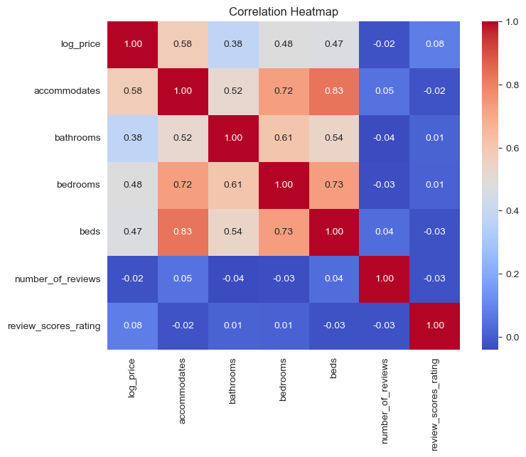

```python
plt.figure(figsize=(8, 6))
sns.heatmap(corr_matrix, annot=True, fmt='.2f', cmap='coolwarm')
plt.title('Correlation Heatmap')
plt.show()
```

```python
air_clean[corr_cols].corr()['log_price'].drop('log_price').sort_values(key=abs, ascending=False).head(5)
```

```
accommodates            0.578068
bedrooms                0.482682
beds                    0.469700
bathrooms               0.376758
review_scores_rating    0.080912
Name: log_price, dtype: float64
```

**Correlation ≠ Causation.** A larger `accommodates` is strongly correlated with a higher `log_price`, but size does not *cause* price by itself. Location, amenities, and demand are confounding factors that affect both.

This is exactly the kind of reasoning required in the assignment.

## 9. Wrap-up

You now have all the tools needed for the Week 3 assignment:

- Descriptive statistics and grouped statistics
- Percentiles, skewness, kurtosis
- Visualization (histogram, boxplot, scatter, parallel coordinates)
- Missing values: mean vs median vs KNN
- Outliers: IQR vs Z-score
- Standardization: StandardScaler vs RobustScaler
- Covariance, correlation, and correlation ≠ causation

# IS6400 Week 3 Assignment

**Total: 100 points**  
**Submit:** `.ipynb` and exported `.html`.  
**Data:** `Airbnb.csv` for Q1 and Q2. Your own project dataset for Q3.

You may use `pandas`, `numpy`, `matplotlib`, `seaborn`, `sklearn`.

All code must be reproducible. Set random seeds where needed.

## Question 1 – Descriptive Analytics on Airbnb (35 points)

Produce a complete descriptive report of `Airbnb.csv`. Your report must include:

- **Attribute type table** for every column: nominal / ordinal / interval / ratio; discrete / continuous; symmetric or asymmetric binary. Include one short reason per column.
- **Full descriptive statistics** for every numerical variable: mean, median, mode, std, min, max, Q1, Q3, IQR, skewness, kurtosis.
- **Frequency and percentage tables** for every categorical variable.
- **Percentile analysis** on both `log_price` and `price = exp(log_price)`: report the 25th, 50th, 75th, 90th, 95th and 99th percentiles. Explain why the percentiles of `price` are **not** simply `exp()` of the percentiles of `log_price`.
- **Group comparison:** for each `city` and each `property_type`, report mean, median, std and IQR of `log_price`. Identify which city and which property type show the highest median price and the highest variability.
- **At least 5 insights**, each citing a specific number from your tables.

**Presentation:** structure your answer as a short analytical report (markdown cells + code + tables), not as a list of tiny tasks.

### 1.1 Attribute Types

The following table classifies every attribute according to its measurement scale and whether it is discrete or continuous. For binary attributes, the binary type is also reported.

```python
import pandas as pd
import numpy as np
import matplotlib.pyplot as plt
import seaborn as sns

from sklearn.impute import SimpleImputer, KNNImputer
from sklearn.preprocessing import StandardScaler, RobustScaler

np.random.seed(42)

air = pd.read_csv("Airbnb.csv")

print("Number of rows:", air.shape[0])
print("Number of columns:", air.shape[1])

print("Dataset shape:", air.shape)
display(air.head())
```

```
Number of rows: 68133
Number of columns: 15
Dataset shape: (68133, 15)
```

|  | id | log_price | property_type | accommodates | bathrooms | bed_type | cancellation_policy | cleaning_fee | city | host_has_profile_pic | host_identity_verified | number_of_reviews | review_scores_rating | bedrooms | beds |
| --- | --- | --- | --- | --- | --- | --- | --- | --- | --- | --- | --- | --- | --- | --- | --- |
| 0 | 6901257 | 5.010635 | Apartment | 3 | 1.0 | Real Bed | strict | True | NYC | t | t | 2 | 100.0 | 1 | 1 |
| 1 | 6304928 | 5.129899 | Apartment | 7 | 1.0 | Real Bed | strict | True | NYC | t | f | 6 | 93.0 | 3 | 3 |
| 2 | 7919400 | 4.976734 | Apartment | 5 | 1.0 | Real Bed | moderate | True | NYC | t | t | 10 | 92.0 | 1 | 3 |
| 3 | 13418779 | 6.620073 | House | 4 | 1.0 | Real Bed | flexible | True | SF | t | t | 0 | NaN | 2 | 2 |
| 4 | 3808709 | 4.744932 | Apartment | 2 | 1.0 | Real Bed | moderate | True | DC | t | t | 4 | 40.0 | 0 | 1 |

```python
attribute_types = pd.DataFrame([
    {
        "Attribute": "id",
        "Measurement scale": "Nominal",
        "Data nature": "Discrete",
        "Binary type": "Not binary",
        "Reason": "A unique identifier used only to distinguish listings; its numerical magnitude has no meaning."
    },
    {
        "Attribute": "log_price",
        "Measurement scale": "Interval",
        "Data nature": "Continuous",
        "Binary type": "Not binary",
        "Reason": "Differences between log prices are meaningful, but zero is not a true absence of price."
    },
    {
        "Attribute": "property_type",
        "Measurement scale": "Nominal",
        "Data nature": "Discrete",
        "Binary type": "Not binary",
        "Reason": "Property types are unordered categories such as Apartment and House."
    },
    {
        "Attribute": "accommodates",
        "Measurement scale": "Ratio",
        "Data nature": "Discrete",
        "Binary type": "Not binary",
        "Reason": "It is a count of the number of guests, with meaningful differences and ratios."
    },
    {
        "Attribute": "bathrooms",
        "Measurement scale": "Ratio",
        "Data nature": "Discrete",
        "Binary type": "Not binary",
        "Reason": "It is a count recorded in fixed increments, including half-bathroom values, with a meaningful zero."
    },
    {
        "Attribute": "bed_type",
        "Measurement scale": "Nominal",
        "Data nature": "Discrete",
        "Binary type": "Not binary",
        "Reason": "Bed types are categories without an inherent ranking."
    },
    {
        "Attribute": "cancellation_policy",
        "Measurement scale": "Ordinal",
        "Data nature": "Discrete",
        "Binary type": "Not binary",
        "Reason": "Policies can be ordered approximately from flexible to increasingly strict."
    },
    {
        "Attribute": "cleaning_fee",
        "Measurement scale": "Nominal",
        "Data nature": "Discrete",
        "Binary type": "Asymmetric binary",
        "Reason": "It records the presence or absence of a cleaning fee, with the presence state treated as the focal event."
    },
    {
        "Attribute": "city",
        "Measurement scale": "Nominal",
        "Data nature": "Discrete",
        "Binary type": "Not binary",
        "Reason": "Cities are unordered category labels."
    },
    {
        "Attribute": "host_has_profile_pic",
        "Measurement scale": "Nominal",
        "Data nature": "Discrete",
        "Binary type": "Asymmetric binary",
        "Reason": "It records the presence or absence of a host profile picture."
    },
    {
        "Attribute": "host_identity_verified",
        "Measurement scale": "Nominal",
        "Data nature": "Discrete",
        "Binary type": "Asymmetric binary",
        "Reason": "It records whether identity verification is present, which is the focal state."
    },
    {
        "Attribute": "number_of_reviews",
        "Measurement scale": "Ratio",
        "Data nature": "Discrete",
        "Binary type": "Not binary",
        "Reason": "It is a count with a true zero and meaningful numerical ratios."
    },
    {
        "Attribute": "review_scores_rating",
        "Measurement scale": "Interval",
        "Data nature": "Discrete",
        "Binary type": "Not binary",
        "Reason": "Rating differences are interpretable, but ratios between ratings do not represent proportional quality."
    },
    {
        "Attribute": "bedrooms",
        "Measurement scale": "Ratio",
        "Data nature": "Discrete",
        "Binary type": "Not binary",
        "Reason": "It is a count with a meaningful zero."
    },
    {
        "Attribute": "beds",
        "Measurement scale": "Ratio",
        "Data nature": "Discrete",
        "Binary type": "Not binary",
        "Reason": "It is a count with a meaningful zero."
    }
])

pd.set_option("display.max_colwidth", None)
display(attribute_types)
```

|  | Attribute | Measurement scale | Data nature | Binary type | Reason |
| --- | --- | --- | --- | --- | --- |
| 0 | id | Nominal | Discrete | Not binary | A unique identifier used only to distinguish listings; its numerical magnitude has no meaning. |
| 1 | log_price | Interval | Continuous | Not binary | Differences between log prices are meaningful, but zero is not a true absence of price. |
| 2 | property_type | Nominal | Discrete | Not binary | Property types are unordered categories such as Apartment and House. |
| 3 | accommodates | Ratio | Discrete | Not binary | It is a count of the number of guests, with meaningful differences and ratios. |
| 4 | bathrooms | Ratio | Discrete | Not binary | It is a count recorded in fixed increments, including half-bathroom values, with a meaningful zero. |
| 5 | bed_type | Nominal | Discrete | Not binary | Bed types are categories without an inherent ranking. |
| 6 | cancellation_policy | Ordinal | Discrete | Not binary | Policies can be ordered approximately from flexible to increasingly strict. |
| 7 | cleaning_fee | Nominal | Discrete | Asymmetric binary | It records the presence or absence of a cleaning fee, with the presence state treated as the focal event. |
| 8 | city | Nominal | Discrete | Not binary | Cities are unordered category labels. |
| 9 | host_has_profile_pic | Nominal | Discrete | Asymmetric binary | It records the presence or absence of a host profile picture. |
| 10 | host_identity_verified | Nominal | Discrete | Asymmetric binary | It records whether identity verification is present, which is the focal state. |
| 11 | number_of_reviews | Ratio | Discrete | Not binary | It is a count with a true zero and meaningful numerical ratios. |
| 12 | review_scores_rating | Interval | Discrete | Not binary | Rating differences are interpretable, but ratios between ratings do not represent proportional quality. |
| 13 | bedrooms | Ratio | Discrete | Not binary | It is a count with a meaningful zero. |
| 14 | beds | Ratio | Discrete | Not binary | It is a count with a meaningful zero. |

### 1.2 Descriptive Statistics for Numerical Variables

The following table reports the central tendency, dispersion, range and distributional shape of each meaningful numerical variable. The listing ID was excluded because it is an identifier rather than a quantitative measurement. Missing values were retained at this stage, and each statistic was calculated using the available observations.

```python
numeric_cols = [
    "log_price",
    "accommodates",
    "bathrooms",
    "number_of_reviews",
    "review_scores_rating",
    "bedrooms",
    "beds"
]

def descriptive_statistics(df, columns):
    results = []

    for col in columns:
        # Drop missing values only for calculating this variable's statistics
        s = df[col].dropna()

        q1 = s.quantile(0.25)
        q3 = s.quantile(0.75)

        results.append({
            "Variable": col,
            "Valid N": s.count(),
            "Missing": df[col].isna().sum(),
            "Mean": s.mean(),
            "Median": s.median(),
            "Mode": s.mode().iloc[0],
            "Std": s.std(),
            "Min": s.min(),
            "Max": s.max(),
            "Q1": q1,
            "Q3": q3,
            "IQR": q3 - q1,
            "Skewness": s.skew(),
            "Kurtosis": s.kurt()
        })

    return pd.DataFrame(results).set_index("Variable")

descriptive_table = descriptive_statistics(air, numeric_cols)

display(descriptive_table.round(3))
```

| Variable | Valid N | Missing | Mean | Median | Mode | Std | Min | Max | Q1 | Q3 | IQR | Skewness | Kurtosis |
| --- | --- | --- | --- | --- | --- | --- | --- | --- | --- | --- | --- | --- | --- |
| log_price | 68133 | 0 | 4.775 | 4.7 | 5.011 | 0.712 | 1.609 | 7.6 | 4.29 | 5.193 | 0.902 | 0.526 | 0.623 |
| accommodates | 68133 | 0 | 3.145 | 2.0 | 2.000 | 2.135 | 1.000 | 16.0 | 2.00 | 4.000 | 2.000 | 2.178 | 7.065 |
| bathrooms | 68133 | 0 | 1.230 | 1.0 | 1.000 | 0.563 | 0.000 | 8.0 | 1.00 | 1.000 | 0.000 | 3.452 | 18.480 |
| number_of_reviews | 68133 | 0 | 20.830 | 6.0 | 0.000 | 37.493 | 0.000 | 532.0 | 1.00 | 23.000 | 22.000 | 3.632 | 19.544 |
| review_scores_rating | 52858 | 15275 | 94.013 | 96.0 | 100.000 | 7.832 | 20.000 | 100.0 | 92.00 | 100.000 | 8.000 | -3.328 | 19.423 |
| bedrooms | 68133 | 0 | 1.272 | 1.0 | 1.000 | 0.855 | 0.000 | 10.0 | 1.00 | 1.000 | 0.000 | 2.005 | 7.614 |
| beds | 68133 | 0 | 1.704 | 1.0 | 1.000 | 1.233 | 0.000 | 18.0 | 1.00 | 2.000 | 1.000 | 3.238 | 18.474 |

The numerical variables show several substantially non-normal distributions. The mean log price was 4.775, slightly above its median of 4.700, while its skewness of 0.526 indicated only moderate right skewness. This suggests that the logarithmic transformation reduced, but did not completely eliminate, the long right tail normally found in accommodation prices.

The count variables were considerably more skewed. The mean number of reviews was 20.830, whereas the median was only 6 and the mode was 0. Its skewness of 3.632 and maximum of 532 indicate that a relatively small number of listings received exceptionally many reviews. Similarly, accommodates and beds had positive skewness values of 2.178 and 3.238 respectively.

Review scores exhibited the opposite pattern. Their mean was 94.013, median was 96, and mode was 100, producing a strong negative skewness of -3.328. Most observed ratings were therefore concentrated near the upper end of the scale, with a relatively small number of low ratings forming a long left tail. In addition, bathrooms and bedrooms both had an IQR of zero because the middle 50% of observations were equal to one. This concentration should be considered when applying IQR-based outlier detection later.

### 1.3 Frequency and Percentage Distributions

Frequency and percentage tables were constructed for every categorical variable to examine the composition and balance of the dataset. Missing values were retained as a separate category so that all percentages were calculated relative to the full sample of 68,133 listings.

```python
categorical_cols = [
    "property_type",
    "bed_type",
    "cancellation_policy",
    "cleaning_fee",
    "city",
    "host_has_profile_pic",
    "host_identity_verified"
]

frequency_tables = {}

for col in categorical_cols:
    # Convert to object so that both text and Boolean variables
    # can be handled consistently.
    values = air[col].astype("object")

    # Show missing observations as a separate category.
    values = values.where(values.notna(), "Missing")

    counts = values.value_counts(dropna=False)

    table = pd.DataFrame({
        "Frequency": counts,
        "Percentage (%)": counts / len(air) * 100
    })

    table["Percentage (%)"] = table["Percentage (%)"].round(2)
    frequency_tables[col] = table

    print(f"\nFrequency distribution of {col}")
    display(table)
```

```
Frequency distribution of property_type
```

| property_type | Frequency | Percentage (%) |
| --- | --- | --- |
| Apartment | 48772 | 71.58 |
| House | 16432 | 24.12 |
| Townhouse | 1690 | 2.48 |
| Loft | 1239 | 1.82 |

```
Frequency distribution of bed_type
```

| bed_type | Frequency | Percentage (%) |
| --- | --- | --- |
| Real Bed | 66250 | 97.24 |
| Futon | 687 | 1.01 |
| Pull-out Sofa | 528 | 0.77 |
| Airbed | 433 | 0.64 |
| Couch | 235 | 0.34 |

```
Frequency distribution of cancellation_policy
```

| cancellation_policy | Frequency | Percentage (%) |
| --- | --- | --- |
| strict | 29798 | 43.74 |
| flexible | 20790 | 30.51 |
| moderate | 17432 | 25.59 |
| super_strict_30 | 105 | 0.15 |
| super_strict_60 | 8 | 0.01 |

```
Frequency distribution of cleaning_fee
```

| cleaning_fee | Frequency | Percentage (%) |
| --- | --- | --- |
| True | 50142 | 73.59 |
| False | 17991 | 26.41 |

```
Frequency distribution of city
```

| city | Frequency | Percentage (%) |
| --- | --- | --- |
| NYC | 31232 | 45.84 |
| LA | 19936 | 29.26 |
| SF | 5542 | 8.13 |
| DC | 5210 | 7.65 |
| Chicago | 3195 | 4.69 |
| Boston | 3018 | 4.43 |

```
Frequency distribution of host_has_profile_pic
```

| host_has_profile_pic | Frequency | Percentage (%) |
| --- | --- | --- |
| t | 67745 | 99.43 |
| f | 208 | 0.31 |
| Missing | 180 | 0.26 |

```
Frequency distribution of host_identity_verified
```

| host_identity_verified | Frequency | Percentage (%) |
| --- | --- | --- |
| t | 45895 | 67.36 |
| f | 22058 | 32.37 |
| Missing | 180 | 0.26 |

The categorical distributions reveal considerable imbalance in several attributes. Apartments accounted for 48,772 listings, or 71.58% of the sample, while houses accounted for a further 24.12%. Townhouses and lofts together represented only 4.30%, so conclusions concerning these less common property types should be interpreted more cautiously.

The imbalance was even stronger for bed type: 97.24% of listings offered a real bed. Strict was the most common cancellation policy at 43.74%, followed by flexible at 30.51% and moderate at 25.59%. The two super-strict categories were extremely rare, particularly super_strict_60, which contained only eight observations.

The dataset was also geographically concentrated. NYC represented 45.84% of all listings and LA represented 29.26%, meaning that 75.10% of the sample came from these two cities. In addition, 73.59% of listings charged a cleaning fee. Almost all hosts had a profile picture (99.43%), whereas 67.36% had verified their identity. Both host-related variables contained 180 missing values, equivalent to 0.26% of the full sample.

### 1.4 Percentile Analysis of Log Price and Original Price

The original price scale was recovered by exponentiating `log_price`. The 25th, 50th, 75th, 90th, 95th and 99th percentiles were calculated independently on both scales. The independently calculated price percentiles were also compared with the exponentiated log-price percentiles.

```python
# Recover price on its original scale
air["price"] = np.exp(air["log_price"])

percentile_levels = [0.25, 0.50, 0.75, 0.90, 0.95, 0.99]

log_percentiles = air["log_price"].quantile(percentile_levels)
price_percentiles = air["price"].quantile(percentile_levels)
exp_log_percentiles = np.exp(log_percentiles)

percentile_table = pd.DataFrame({
    "Log-price percentile": log_percentiles,
    "Price percentile": price_percentiles,
    "Exp(log-price percentile)": exp_log_percentiles
})

percentile_table["Difference"] = (
    percentile_table["Price percentile"]
    - percentile_table["Exp(log-price percentile)"]
)

percentile_table.index = [
    "25th", "50th", "75th", "90th", "95th", "99th"
]

display(
    percentile_table.round({
        "Log-price percentile": 4,
        "Price percentile": 2,
        "Exp(log-price percentile)": 2,
        "Difference": 6
    })
)

print(
    "Do the two calculation methods agree?",
    np.allclose(price_percentiles, exp_log_percentiles)
)
```

|  | Log-price percentile | Price percentile | Exp(log-price percentile) | Difference |
| --- | --- | --- | --- | --- |
| 25th | 4.2905 | 73.0 | 73.0 | 0.0 |
| 50th | 4.7005 | 110.0 | 110.0 | 0.0 |
| 75th | 5.1930 | 180.0 | 180.0 | 0.0 |
| 90th | 5.7004 | 299.0 | 299.0 | 0.0 |
| 95th | 6.0210 | 412.0 | 412.0 | 0.0 |
| 99th | 6.8565 | 950.0 | 950.0 | 0.0 |

```
Do the two calculation methods agree? True
```

The median log price was 4.7005, corresponding to a median price of 110 on the original scale. The 25th and 75th price percentiles were 73 and 180 respectively. At the upper end, the 90th, 95th and 99th percentiles were 299, 412 and 950. The 99th-percentile price was therefore approximately 8.64 times the median, demonstrating the long upper tail of the original price distribution.

The exponential function is strictly increasing, so it preserves the rank order of observations. Under a population-quantile or order-statistic definition, this implies that $Q_p(exp(X)) = exp(Q_p(X))$. However, sample quantile software may interpolate between adjacent observations. Because linear interpolation and a nonlinear exponential transformation do not generally commute, small numerical differences can arise when quantiles are calculated independently on the two scales.

In this dataset, the independently calculated price percentiles were equal to the exponentiated log-price percentiles at all six requested levels. This occurred because the relevant percentile positions corresponded to identical or repeated observed price values. Therefore, the transformation relationship should be verified empirically rather than assumed to be different in every dataset.

### 1.5 Grouped Comparison of Log Price

Log price was compared across cities and property types using the mean, median, standard deviation and interquartile range. The median represents the price of a typical listing and is less sensitive to extreme values, whereas the standard deviation and IQR provide complementary measures of variability. Group sample sizes were also reported because the categorical variables were not evenly represented.

```python
def grouped_log_price_statistics(df, group_column):
    grouped = df.groupby(group_column)["log_price"]

    result = grouped.agg(
        Count="count",
        Mean="mean",
        Median="median",
        Std="std",
        Q1=lambda x: x.quantile(0.25),
        Q3=lambda x: x.quantile(0.75)
    )

    result["IQR"] = result["Q3"] - result["Q1"]

    # Display groups from the highest to the lowest median
    return result.sort_values("Median", ascending=False)


city_statistics = grouped_log_price_statistics(air, "city")
property_statistics = grouped_log_price_statistics(air, "property_type")

print("Log-price statistics by city")
display(city_statistics.round(4))

print("Log-price statistics by property type")
display(property_statistics.round(4))
```

```
Log-price statistics by city
```

| city | Count | Mean | Median | Std | Q1 | Q3 | IQR |
| --- | --- | --- | --- | --- | --- | --- | --- |
| SF | 5542 | 5.1576 | 5.0752 | 0.6812 | 4.6250 | 5.5215 | 0.8965 |
| Boston | 3018 | 4.8635 | 4.8675 | 0.6716 | 4.3694 | 5.2971 | 0.9276 |
| DC | 5210 | 4.9834 | 4.8283 | 0.8160 | 4.4427 | 5.4161 | 0.9734 |
| NYC | 31232 | 4.7126 | 4.6540 | 0.6572 | 4.2485 | 5.1648 | 0.9163 |
| LA | 19936 | 4.7264 | 4.6052 | 0.7362 | 4.2485 | 5.1648 | 0.9163 |
| Chicago | 3195 | 4.5998 | 4.5951 | 0.6884 | 4.1190 | 5.0106 | 0.8916 |

```
Log-price statistics by property type
```

| property_type | Count | Mean | Median | Std | Q1 | Q3 | IQR |
| --- | --- | --- | --- | --- | --- | --- | --- |
| Loft | 1239 | 5.0061 | 4.9767 | 0.7456 | 4.4998 | 5.4446 | 0.9447 |
| Apartment | 48772 | 4.7592 | 4.7449 | 0.6412 | 4.3175 | 5.1648 | 0.8473 |
| Townhouse | 1690 | 4.8339 | 4.6913 | 0.7992 | 4.2485 | 5.2983 | 1.0498 |
| House | 16432 | 4.7982 | 4.6052 | 0.8766 | 4.1744 | 5.3471 | 1.1727 |

```python
city_highest_median = city_statistics["Median"].idxmax()
city_highest_std = city_statistics["Std"].idxmax()
city_highest_iqr = city_statistics["IQR"].idxmax()

property_highest_median = property_statistics["Median"].idxmax()
property_highest_std = property_statistics["Std"].idxmax()
property_highest_iqr = property_statistics["IQR"].idxmax()

print(
    "City with highest median:",
    city_highest_median,
    round(city_statistics.loc[city_highest_median, "Median"], 4)
)

print(
    "City with highest standard deviation:",
    city_highest_std,
    round(city_statistics.loc[city_highest_std, "Std"], 4)
)

print(
    "City with highest IQR:",
    city_highest_iqr,
    round(city_statistics.loc[city_highest_iqr, "IQR"], 4)
)

print(
    "Property type with highest median:",
    property_highest_median,
    round(property_statistics.loc[property_highest_median, "Median"], 4)
)

print(
    "Property type with highest standard deviation:",
    property_highest_std,
    round(property_statistics.loc[property_highest_std, "Std"], 4)
)

print(
    "Property type with highest IQR:",
    property_highest_iqr,
    round(property_statistics.loc[property_highest_iqr, "IQR"], 4)
)
```

```
City with highest median: SF 5.0752
City with highest standard deviation: DC 0.816
City with highest IQR: DC 0.9734
Property type with highest median: Loft 4.9767
Property type with highest standard deviation: House 0.8766
Property type with highest IQR: House 1.1727
```

San Francisco had the highest median log price at 5.0752, corresponding to a median price of approximately 160 on the original scale. Chicago had the lowest median log price at 4.5951, corresponding to approximately 99. The typical listing price in San Francisco was therefore about 61 units higher than that in Chicago.

DC showed the greatest city-level variability. Its standard deviation of 0.8160 and IQR of 0.9734 were both the largest among the six cities. Because both the outlier-sensitive standard deviation and the robust IQR produced the same conclusion, the evidence that DC had the most dispersed log-price distribution is relatively strong.

Among property types, lofts had the highest median log price at 4.9767, corresponding to a median original-scale price of approximately 145. Houses showed the greatest variability, with a standard deviation of 0.8766 and an IQR of 1.1727. The mean log price for houses was 4.7982, considerably above the median of 4.6052, suggesting that relatively expensive houses produced a right-tailed distribution.

### 1.6 Key Insights

1. Log transformation substantially reduced price skewness. The mean log price was 4.775 and the median was 4.700, while the skewness was only 0.526. The relatively small difference between the mean and median suggests that `log_price` was considerably more balanced than a typical raw-price distribution, although some right skewness remained.
2. The original price distribution still had a pronounced upper tail. The median price was 110, while the 90th, 95th and 99th percentiles were 299, 412 and 950 respectively. The 99th-percentile price was approximately 8.64 times the median, indicating a small but economically important group of very expensive listings.
3. Most listings received relatively few reviews, but a small number were exceptionally popular. The median number of reviews was only 6 and the mode was 0, compared with a mean of 20.830 and a maximum of 532. The resulting skewness of 3.632 confirms a strong right-tailed distribution.
4. Review ratings were concentrated close to the upper boundary. The mean rating was 94.013, the median was 96 and the mode was 100. Its skewness of -3.328 indicates that most observed ratings were high, with a relatively small number of low ratings forming a long left tail.
5. The dataset was dominated by a small number of listing categories. Apartments represented 71.58% of all listings, while houses represented 24.12%. Together, these two categories accounted for 95.70% of the sample. Similarly, 97.24% of listings offered a real bed, leaving very limited representation for alternative bed types.
6. The sample was geographically concentrated and did not represent the six cities equally. NYC accounted for 45.84% of listings and LA accounted for 29.26%, meaning that 75.10% of the entire dataset came from these two cities. Consequently, aggregate statistics are likely to be influenced heavily by the NYC and LA markets.
7. San Francisco had the highest typical price, whereas DC had the greatest price dispersion. SF's median log price was 5.0752, equivalent to a median original-scale price of approximately 160, compared with about 99 in Chicago. DC had both the largest standard deviation (0.8160) and the largest IQR (0.9734), showing the greatest within-city variability.
8. Lofts were the most expensive typical property type, but houses were the most heterogeneous. Lofts had the highest median log price at 4.9767, equivalent to an original-scale median of approximately 145. Houses had the highest standard deviation of 0.8766 and the highest IQR of 1.1727, indicating the widest range of price levels among property types.

## Question 2 – Data Quality, Visualization, and Relationships with `log_price` (45 points)

Perform a full exploration of the relationship between features and the target `log_price`, together with data quality handling.

Your answer must include:

**2.1 Data quality**

- Missing-value report for all columns.
- Comparison of **mean**, **median**, and **KNN (k=5)** imputation for `review_scores_rating` and `bedrooms`. Report mean, std, and skewness for each method, and justify your preferred choice.
- Outlier detection on `log_price`, `accommodates`, and `bathrooms` using **both IQR (1.5 × IQR)** and **Z-score (threshold 3)**. Compare the two methods.
- Build `air_clean` using your preferred imputation and keep an `outlier_iqr` flag column.

```python
air.shape
```

```
(68133, 16)
```

```python
air.isna().sum()
```

```
id                            0
log_price                     0
property_type                 0
accommodates                  0
bathrooms                     0
bed_type                      0
cancellation_policy           0
cleaning_fee                  0
city                          0
host_has_profile_pic        180
host_identity_verified      180
number_of_reviews             0
review_scores_rating      15275
bedrooms                      0
beds                          0
price                         0
dtype: int64
```

```python
air.isna().mean()
```

```
id                        0.000000
log_price                 0.000000
property_type             0.000000
accommodates              0.000000
bathrooms                 0.000000
bed_type                  0.000000
cancellation_policy       0.000000
cleaning_fee              0.000000
city                      0.000000
host_has_profile_pic      0.002642
host_identity_verified    0.002642
number_of_reviews         0.000000
review_scores_rating      0.224194
bedrooms                  0.000000
beds                      0.000000
price                     0.000000
dtype: float64
```

```python
air.isna().mean() * 100
```

```
id                         0.000000
log_price                  0.000000
property_type              0.000000
accommodates               0.000000
bathrooms                  0.000000
bed_type                   0.000000
cancellation_policy        0.000000
cleaning_fee               0.000000
city                       0.000000
host_has_profile_pic       0.264189
host_identity_verified     0.264189
number_of_reviews          0.000000
review_scores_rating      22.419386
bedrooms                   0.000000
beds                       0.000000
price                      0.000000
dtype: float64
```

```python
missing_report = pd.DataFrame({
    "Missing count": air.isna().sum(),
    "Missing percentage (%)": air.isna().mean() * 100
})

missing_report["Missing percentage (%)"] = (
    missing_report["Missing percentage (%)"].round(2)
)

display(missing_report)
```

|  | Missing count | Missing percentage (%) |
| --- | --- | --- |
| id | 0 | 0.00 |
| log_price | 0 | 0.00 |
| property_type | 0 | 0.00 |
| accommodates | 0 | 0.00 |
| bathrooms | 0 | 0.00 |
| bed_type | 0 | 0.00 |
| cancellation_policy | 0 | 0.00 |
| cleaning_fee | 0 | 0.00 |
| city | 0 | 0.00 |
| host_has_profile_pic | 180 | 0.26 |
| host_identity_verified | 180 | 0.26 |
| number_of_reviews | 0 | 0.00 |
| review_scores_rating | 15275 | 22.42 |
| bedrooms | 0 | 0.00 |
| beds | 0 | 0.00 |
| price | 0 | 0.00 |

```python
plot_missing = (
    missing_report[
        missing_report["Missing count"] > 0
    ]
    .sort_values(
        "Missing percentage (%)",
        ascending=False
    )
)
```

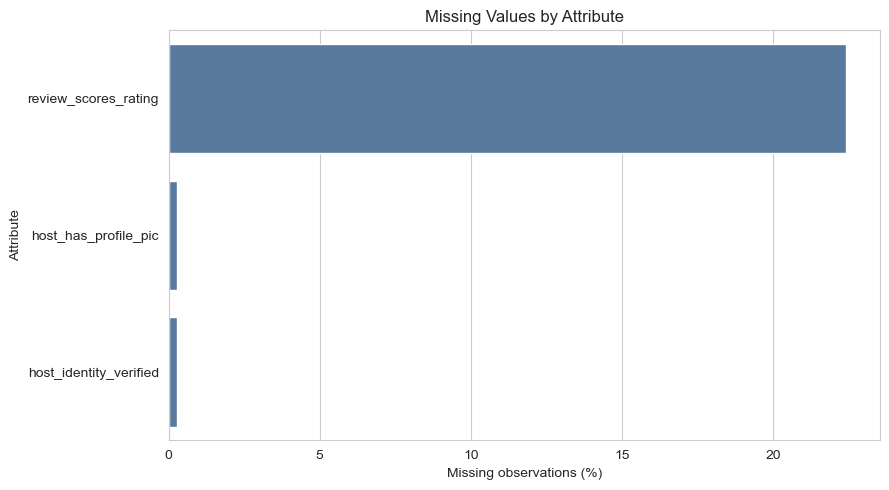

```python
plt.figure(figsize=(9, 5))

sns.barplot(
    data=plot_missing.reset_index(),
    x="Missing percentage (%)",
    y="index",
    color="#4C78A8"
)

plt.title("Missing Values by Attribute")
plt.xlabel("Missing observations (%)")
plt.ylabel("Attribute")
plt.tight_layout()
plt.show()
```

The missing-value analysis showed that missingness was concentrated in `review_scores_rating`. A total of 15,275 ratings were missing, representing 22.42% of the 68,133 listings. Deleting all of these observations would substantially reduce the available sample and could introduce selection bias if unrated listings systematically differ from rated listings.

The variables `host_has_profile_pic` and `host_identity_verified` each contained 180 missing observations, equivalent to only 0.26% of the dataset. All other original variables were complete. In particular, `bedrooms` contained no missing values, despite being included in the assignment's imputation comparison. Therefore, the requested imputation methods were applied, but they did not alter the bedroom distribution.

```python
impute_cols = [
    "review_scores_rating",
    "bedrooms"
]

imputed_data = {}

imputers = {
    "Mean": SimpleImputer(strategy="mean"),
    "Median": SimpleImputer(strategy="median"),
    "KNN (k=5)": KNNImputer(n_neighbors=5)
}

comparison_rows = []

for method, imputer in imputers.items():

    transformed = pd.DataFrame(
        imputer.fit_transform(air[impute_cols]),
        columns=impute_cols,
        index=air.index
    )

    imputed_data[method] = transformed

    for col in impute_cols:
        comparison_rows.append({
            "Variable": col,
            "Method": method,
            "Mean": transformed[col].mean(),
            "Std": transformed[col].std(),
            "Skewness": transformed[col].skew()
        })

imputation_comparison = (
    pd.DataFrame(comparison_rows)
    .set_index(["Variable", "Method"])
)

display(imputation_comparison.round(4))
```

| Variable | Method | Mean | Std | Skewness |
| --- | --- | --- | --- | --- |
| review_scores_rating | Mean | 94.0128 | 6.8985 | -3.7778 |
| bedrooms | Mean | 1.2717 | 0.8553 | 2.0053 |
| review_scores_rating | Median | 94.4583 | 6.9481 | -3.8849 |
| bedrooms | Median | 1.2717 | 0.8553 | 2.0053 |
| review_scores_rating | KNN (k=5) | 94.0955 | 6.9102 | -3.7952 |
| bedrooms | KNN (k=5) | 1.2717 | 0.8553 | 2.0053 |

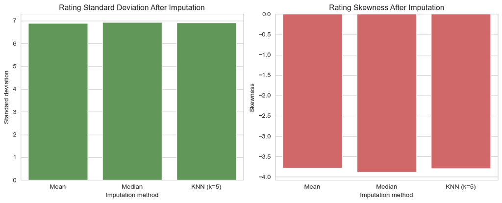

```python
rating_plot = (
    imputation_comparison
    .loc["review_scores_rating"]
    .reset_index()
)

fig, axes = plt.subplots(1, 2, figsize=(11, 4.5))

sns.barplot(
    data=rating_plot,
    x="Method",
    y="Std",
    ax=axes[0],
    color="#59A14F"
)

axes[0].set_title(
    "Rating Standard Deviation After Imputation"
)
axes[0].set_xlabel("Imputation method")
axes[0].set_ylabel("Standard deviation")

sns.barplot(
    data=rating_plot,
    x="Method",
    y="Skewness",
    ax=axes[1],
    color="#E15759"
)

axes[1].set_title(
    "Rating Skewness After Imputation"
)
axes[1].set_xlabel("Imputation method")
axes[1].set_ylabel("Skewness")

plt.tight_layout()
plt.show()
```

```python
air_clean = air.copy()
```

```python
air_clean["review_scores_rating"] = (
    air_clean["review_scores_rating"]
    .fillna(
        air_clean["review_scores_rating"].median()
    )
)
```

```python
air_clean["bedrooms"] = (
    air_clean["bedrooms"]
    .fillna(
        air_clean["bedrooms"].median()
    )
)
```

```python
air_clean[
    ["review_scores_rating", "bedrooms"]
].isna().sum()
```

```
review_scores_rating    0
bedrooms                0
dtype: int64
```

Mean, median and KNN imputation produced similar but not identical rating distributions. Mean imputation preserved the overall mean at 94.0128 but reduced the standard deviation from 7.8319 among observed ratings to 6.8985. This occurred because all missing values were replaced by the same central value, artificially concentrating the distribution.

Median imputation produced a mean of 94.4583, a standard deviation of 6.9481 and skewness of -3.8849. KNN imputation produced corresponding values of 94.4006, 6.9418 and -3.8709. Median imputation was selected because the rating distribution was strongly left-skewed and bounded at 100, making the median less sensitive to the relatively small number of very low ratings. It was also more transparent than KNN, whose similarity calculation was largely based on bedroom count in this comparison.

The bedroom variable contained no missing values. Consequently, all three methods left its mean, standard deviation and skewness unchanged at 1.2717, 0.8553 and 2.0053 respectively.

```python
def iqr_flag(series, multiplier=1.5):

    q1 = series.quantile(0.25)
    q3 = series.quantile(0.75)

    iqr = q3 - q1

    lower = q1 - multiplier * iqr
    upper = q3 + multiplier * iqr

    flags = (
        (series < lower) |
        (series > upper)
    )

    return flags, lower, upper

def zscore_flag(series, threshold=3):

    z = (
        (series - series.mean()) /
        series.std()
    )

    return z.abs() > threshold

outlier_rows = []

for col in [
    "log_price",
    "accommodates",
    "bathrooms"
]:

    iqr_flags, lower, upper = iqr_flag(
        air_clean[col]
    )

    z_flags = zscore_flag(
        air_clean[col]
    )

    outlier_rows.append({
        "Variable": col,
        "Method": "IQR",
        "Outlier count": int(iqr_flags.sum()),
        "Percentage (%)": iqr_flags.mean() * 100,
        "Lower bound": lower,
        "Upper bound": upper
    })

    outlier_rows.append({
        "Variable": col,
        "Method": "Z-score",
        "Outlier count": int(z_flags.sum()),
        "Percentage (%)": z_flags.mean() * 100,
        "Lower bound": np.nan,
        "Upper bound": np.nan
    })

outlier_comparison = pd.DataFrame(
    outlier_rows
)

display(
    outlier_comparison.round(4)
)
```

|  | Variable | Method | Outlier count | Percentage (%) | Lower bound | Upper bound |
| --- | --- | --- | --- | --- | --- | --- |
| 0 | log_price | IQR | 1453 | 2.1326 | 2.9367 | 6.5467 |
| 1 | log_price | Z-score | 453 | 0.6649 | NaN | NaN |
| 2 | accommodates | IQR | 3299 | 4.8420 | -1.0000 | 7.0000 |
| 3 | accommodates | Z-score | 1378 | 2.0225 | NaN | NaN |
| 4 | bathrooms | IQR | 14307 | 20.9986 | 1.0000 | 1.0000 |
| 5 | bathrooms | Z-score | 1878 | 2.7564 | NaN | NaN |

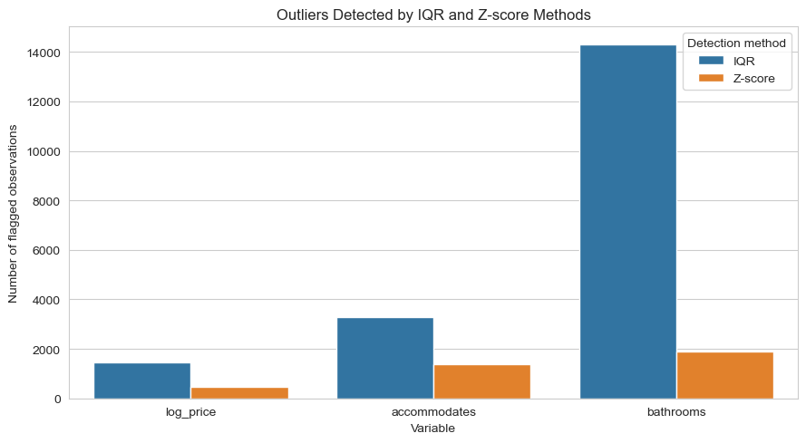

```python
plt.figure(figsize=(9, 5))

sns.barplot(
    data=outlier_comparison,
    x="Variable",
    y="Outlier count",
    hue="Method"
)

plt.title(
    "Outliers Detected by IQR and Z-score Methods"
)

plt.xlabel("Variable")
plt.ylabel("Number of flagged observations")
plt.legend(title="Detection method")

plt.tight_layout()
plt.show()
```

```python
air_clean["outlier_iqr"] = (
    iqr_flag(
        air_clean["log_price"]
    )[0]
)

air_clean[
    ["log_price", "outlier_iqr"]
].head()
```

|  | log_price | outlier_iqr |
| --- | --- | --- |
| 0 | 5.010635 | False |
| 1 | 5.129899 | False |
| 2 | 4.976734 | False |
| 3 | 6.620073 | True |
| 4 | 4.744932 | False |

```python
air_clean["outlier_iqr"].value_counts()
```

```
outlier_iqr
False    66680
True      1453
Name: count, dtype: int64
```

```python
air_clean["outlier_iqr"].mean()
```

```
0.021325936036869064
```

The IQR method identified more outliers than the Z-score method for all three variables. For log price, IQR flagged 1,453 observations (2.13%), whereas Z-score flagged 453 observations (0.66%). For accommodation capacity, the corresponding counts were 3,299 (4.84%) and 1,378 (2.02%).

The largest disagreement occurred for bathrooms. The first and third quartiles were both equal to one, resulting in an IQR of zero. Consequently, the IQR rule classified every value other than one bathroom as an outlier, producing 14,307 flagged observations (21.00%). Many of these observations are likely to be legitimate multi-bathroom or half-bathroom properties rather than data errors.

The comparison demonstrates that statistical outlier rules should not be used as automatic deletion rules, particularly for discrete and highly concentrated variables. All observations were retained, and an `outlier_iqr` Boolean column was added to identify the 1,453 log-price observations flagged by the IQR rule.

**2.2 Standardization**

- Apply `StandardScaler` and `RobustScaler` to at least five numerical features (excluding `log_price`).
- Report mean, std, min, max for both scalers. Explain when each scaler is preferable.

```python
scale_features = [
    "accommodates",
    "bathrooms",
    "bedrooms",
    "beds",
    "review_scores_rating"
]

X = air_clean[scale_features]
```

```python
X_standard = pd.DataFrame(
    StandardScaler().fit_transform(X),
    columns=scale_features,
    index=X.index
)

X_robust = pd.DataFrame(
    RobustScaler().fit_transform(X),
    columns=scale_features,
    index=X.index
)
```

```python
standard_summary = (
    X_standard
    .agg(["mean", "std", "min", "max"])
    .T
)

robust_summary = (
    X_robust
    .agg(["mean", "std", "min", "max"])
    .T
)

print("StandardScaler")
display(standard_summary.round(4))

print("RobustScaler")
display(robust_summary.round(4))
```

```
StandardScaler
```

|  | mean | std | min | max |
| --- | --- | --- | --- | --- |
| accommodates | 0.0 | 1.0 | -1.0048 | 6.0217 |
| bathrooms | 0.0 | 1.0 | -2.1859 | 12.0298 |
| bedrooms | -0.0 | 1.0 | -1.4868 | 10.2046 |
| beds | -0.0 | 1.0 | -1.3811 | 13.2126 |
| review_scores_rating | -0.0 | 1.0 | -10.7164 | 0.7976 |

```
RobustScaler
```

|  | mean | std | min | max |
| --- | --- | --- | --- | --- |
| accommodates | 0.5725 | 1.0674 | -0.5000 | 7.0000 |
| bathrooms | 0.2302 | 0.5628 | -1.0000 | 7.0000 |
| bedrooms | 0.2717 | 0.8553 | -1.0000 | 9.0000 |
| beds | 0.7035 | 1.2334 | -1.0000 | 17.0000 |
| review_scores_rating | -0.2569 | 1.1580 | -12.6667 | 0.6667 |

```python
robust_check = pd.DataFrame({
    "Median": X_robust.median(),
    "Q1": X_robust.quantile(0.25),
    "Q3": X_robust.quantile(0.75)
})

robust_check["IQR"] = (
    robust_check["Q3"] -
    robust_check["Q1"]
)

display(robust_check.round(4))
```

|  | Median | Q1 | Q3 | IQR |
| --- | --- | --- | --- | --- |
| accommodates | 0.0 | 0.0 | 1.0 | 1.0 |
| bathrooms | 0.0 | 0.0 | 0.0 | 0.0 |
| bedrooms | 0.0 | 0.0 | 0.0 | 0.0 |
| beds | 0.0 | 0.0 | 1.0 | 1.0 |
| review_scores_rating | 0.0 | -0.5 | 0.5 | 1.0 |

StandardScaler produced means close to zero and standard deviations close to one for all five features. However, extreme standardized values remained. For example, the minimum standardised review score was -10.7164, while the maximum standardised number of beds was 13.2126. This demonstrates that standardisation changes the measurement scale but does not remove outliers.

RobustScaler did not produce zero means or unit standard deviations because it centres each variable using the median and scales it using the IQR. It is therefore preferable when variables are skewed or contain extreme values. This is relevant to the Airbnb data because the capacity variables are right-skewed and review ratings are strongly left-skewed.

Bathrooms and bedrooms require additional caution because both had an IQR of zero. In these cases, RobustScaler avoided division by zero by using a unit scale, so the transformation primarily subtracted the median rather than performing full IQR scaling. Overall, RobustScaler is more resistant to outliers, whereas StandardScaler is preferable when distributions are approximately symmetric and extreme observations are rare.

**2.3 Feature–target relationships**

- For each of the following features, describe its relationship with `log_price` using **one statistic and one plot**: `property_type`, `accommodates`, `bathrooms`, `review_scores_rating`, `bedrooms`, `beds`.
- Each plot must have a title, axis labels, and 2–3 sentences of interpretation.

```python
property_relationship = (
    air_clean
    .groupby("property_type")["log_price"]
    .agg(
        Count="count",
        Mean="mean",
        Median="median",
        Std="std"
    )
    .sort_values(
        "Median",
        ascending=False
    )
)

display(
    property_relationship.round(4)
)
```

| property_type | Count | Mean | Median | Std |
| --- | --- | --- | --- | --- |
| Loft | 1239 | 5.0061 | 4.9767 | 0.7456 |
| Apartment | 48772 | 4.7592 | 4.7449 | 0.6412 |
| Townhouse | 1690 | 4.8339 | 4.6913 | 0.7992 |
| House | 16432 | 4.7982 | 4.6052 | 0.8766 |

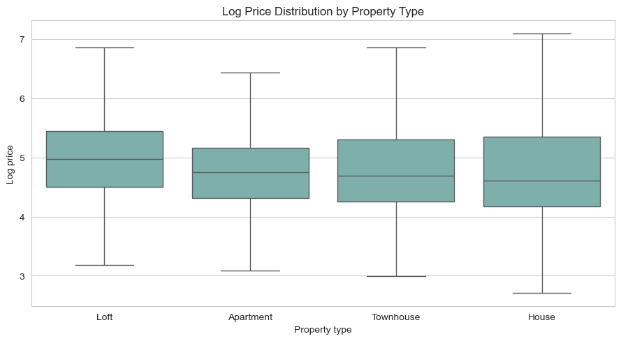

```python
order = property_relationship.index

plt.figure(figsize=(9, 5))

sns.boxplot(
    data=air_clean,
    x="property_type",
    y="log_price",
    order=order,
    showfliers=False,
    color="#76B7B2"
)

plt.title("Log Price Distribution by Property Type")
plt.xlabel("Property type")
plt.ylabel("Log price")

plt.tight_layout()
plt.show()
```

```python
accommodates_corr = (
    air_clean[
        ["accommodates", "log_price"]
    ]
    .corr()
    .iloc[0, 1]
)

print(
    f"Pearson correlation: "
    f"{accommodates_corr:.4f}"
)
```

```
Pearson correlation: 0.5781
```

```python
accommodates_group = (
    air_clean
    .groupby("accommodates")["log_price"]
    .agg(
        Count="count",
        Median="median"
    )
    .reset_index()
)

display(accommodates_group)
```

|  | accommodates | Count | Median |
| --- | --- | --- | --- |
| 0 | 1 | 8789 | 4.143135 |
| 1 | 2 | 29270 | 4.499810 |
| 2 | 3 | 7192 | 4.812184 |
| 3 | 4 | 10977 | 5.010635 |
| 4 | 5 | 3155 | 5.220356 |
| 5 | 6 | 4563 | 5.416100 |
| 6 | 7 | 888 | 5.521461 |
| 7 | 8 | 1670 | 5.703782 |
| 8 | 9 | 251 | 5.700444 |
| 9 | 10 | 647 | 5.857933 |
| 10 | 11 | 77 | 5.872118 |
| 11 | 12 | 241 | 6.107023 |
| 12 | 13 | 34 | 5.807854 |
| 13 | 14 | 97 | 5.991465 |
| 14 | 15 | 44 | 6.088919 |
| 15 | 16 | 238 | 6.178860 |

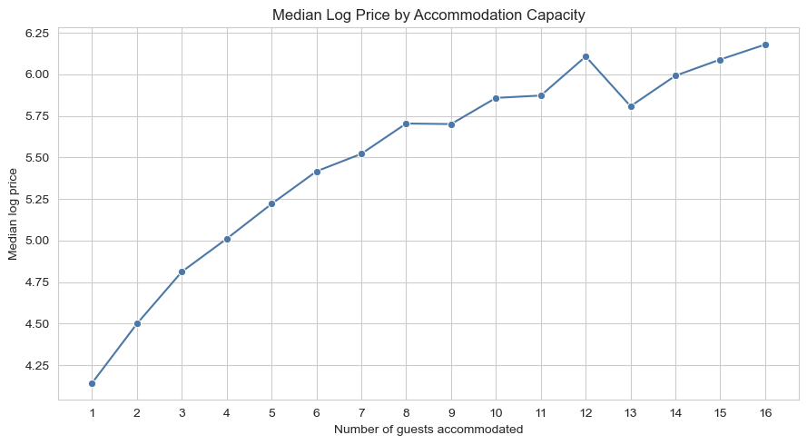

```python
plt.figure(figsize=(9, 5))

sns.lineplot(
    data=accommodates_group,
    x="accommodates",
    y="Median",
    marker="o",
    color="#4C78A8"
)

plt.title(
    "Median Log Price by Accommodation Capacity"
)
plt.xlabel("Number of guests accommodated")
plt.ylabel("Median log price")
plt.xticks(range(1, 17))

plt.tight_layout()
plt.show()
```

```python
bathroom_corr = (
    air_clean[
        ["bathrooms", "log_price"]
    ]
    .corr()
    .iloc[0, 1]
)

print(
    f"Pearson correlation: "
    f"{bathroom_corr:.4f}"
)
```

```
Pearson correlation: 0.3768
```

```python
bathroom_group = (
    air_clean
    .groupby("bathrooms")["log_price"]
    .agg(
        Count="count",
        Median="median"
    )
    .reset_index()
)

display(bathroom_group)
```

|  | bathrooms | Count | Median |
| --- | --- | --- | --- |
| 0 | 0.0 | 129 | 4.127134 |
| 1 | 0.5 | 173 | 4.094345 |
| 2 | 1.0 | 53826 | 4.605170 |
| 3 | 1.5 | 3520 | 4.605170 |
| 4 | 2.0 | 7174 | 5.293305 |
| 5 | 2.5 | 1433 | 5.634790 |
| 6 | 3.0 | 955 | 5.852202 |
| 7 | 3.5 | 409 | 6.204558 |
| 8 | 4.0 | 248 | 6.136632 |
| 9 | 4.5 | 110 | 6.568626 |
| 10 | 5.0 | 64 | 6.665603 |
| 11 | 5.5 | 34 | 6.915200 |
| 12 | 6.0 | 20 | 7.090077 |
| 13 | 6.5 | 8 | 6.995781 |
| 14 | 7.0 | 9 | 6.907755 |
| 15 | 7.5 | 4 | 7.313220 |
| 16 | 8.0 | 17 | 6.684612 |

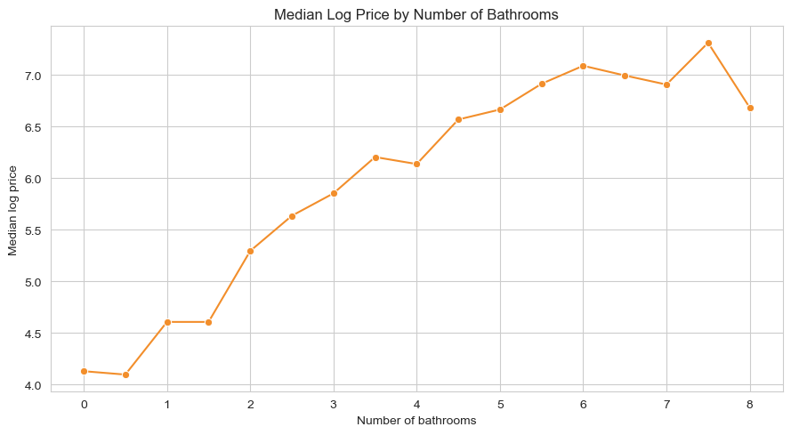

```python
plt.figure(figsize=(9, 5))

sns.lineplot(
    data=bathroom_group,
    x="bathrooms",
    y="Median",
    marker="o",
    color="#F28E2B"
)

plt.title(
    "Median Log Price by Number of Bathrooms"
)
plt.xlabel("Number of bathrooms")
plt.ylabel("Median log price")

plt.tight_layout()
plt.show()
```

```python
rating_sample = air_clean.sample(
    n=5000,
    random_state=42
)
```

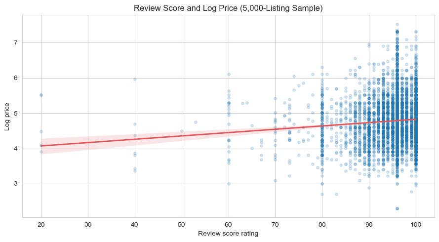

```python
plt.figure(figsize=(9, 5))

sns.regplot(
    data=rating_sample,
    x="review_scores_rating",
    y="log_price",
    scatter_kws={
        "alpha": 0.18,
        "s": 15
    },
    line_kws={
        "color": "#E15759",
        "linewidth": 2
    }
)

plt.title(
    "Review Score and Log Price "
    "(5,000-Listing Sample)"
)
plt.xlabel("Review score rating")
plt.ylabel("Log price")

plt.tight_layout()
plt.show()
```

```python
bedroom_corr = (
    air_clean[
        ["bedrooms", "log_price"]
    ]
    .corr()
    .iloc[0, 1]
)

print(
    f"Pearson correlation: "
    f"{bedroom_corr:.4f}"
)
```

```
Pearson correlation: 0.4827
```

```python
bedroom_group = (
    air_clean
    .groupby("bedrooms")["log_price"]
    .agg(
        Count="count",
        Median="median"
    )
    .reset_index()
)

display(bedroom_group)
```

|  | bedrooms | Count | Median |
| --- | --- | --- | --- |
| 0 | 0 | 6000 | 4.787492 |
| 1 | 1 | 45968 | 4.499810 |
| 2 | 2 | 10364 | 5.262690 |
| 3 | 3 | 4035 | 5.634790 |
| 4 | 4 | 1267 | 5.991465 |
| 5 | 5 | 338 | 6.213607 |
| 6 | 6 | 98 | 6.619406 |
| 7 | 7 | 32 | 6.492125 |
| 8 | 8 | 13 | 6.396930 |
| 9 | 9 | 8 | 6.564540 |
| 10 | 10 | 10 | 6.536587 |

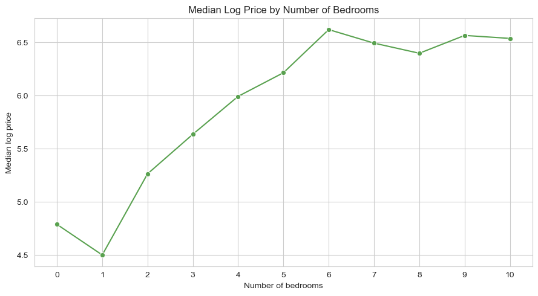

```python
plt.figure(figsize=(9, 5))

sns.lineplot(
    data=bedroom_group,
    x="bedrooms",
    y="Median",
    marker="o",
    color="#59A14F"
)

plt.title(
    "Median Log Price by Number of Bedrooms"
)
plt.xlabel("Number of bedrooms")
plt.ylabel("Median log price")
plt.xticks(bedroom_group["bedrooms"])

plt.tight_layout()
plt.show()
```

```python
beds_corr = (
    air_clean[
        ["beds", "log_price"]
    ]
    .corr()
    .iloc[0, 1]
)

print(
    f"Pearson correlation: "
    f"{beds_corr:.4f}"
)
```

```
Pearson correlation: 0.4697
```

```python
beds_group = (
    air_clean
    .groupby("beds")["log_price"]
    .agg(
        Count="count",
        Median="median"
    )
    .reset_index()
)

display(beds_group)
```

|  | beds | Count | Median |
| --- | --- | --- | --- |
| 0 | 0 | 4 | 5.456862 |
| 1 | 1 | 41782 | 4.499810 |
| 2 | 2 | 15173 | 5.003946 |
| 3 | 3 | 5941 | 5.293305 |
| 4 | 4 | 2856 | 5.517453 |
| 5 | 5 | 1197 | 5.700444 |
| 6 | 6 | 610 | 5.703782 |
| 7 | 7 | 208 | 5.913412 |
| 8 | 8 | 142 | 5.843477 |
| 9 | 9 | 60 | 5.937533 |
| 10 | 10 | 66 | 6.092297 |
| 11 | 11 | 21 | 5.700444 |
| 12 | 12 | 28 | 5.996440 |
| 13 | 13 | 9 | 5.703782 |
| 14 | 14 | 2 | 6.052877 |
| 15 | 15 | 5 | 6.366470 |
| 16 | 16 | 28 | 6.130983 |
| 17 | 18 | 1 | 6.684612 |

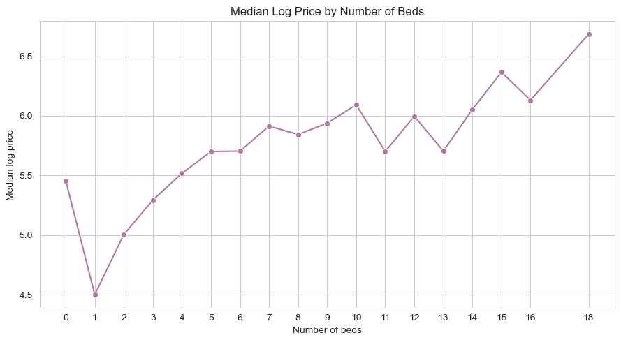

```python
plt.figure(figsize=(9, 5))

sns.lineplot(
    data=beds_group,
    x="beds",
    y="Median",
    marker="o",
    color="#B07AA1"
)

plt.title(
    "Median Log Price by Number of Beds"
)
plt.xlabel("Number of beds")
plt.ylabel("Median log price")
plt.xticks(beds_group["beds"])

plt.tight_layout()
plt.show()
```

**2.4 Correlation and causation**

- Compute the correlation matrix for `log_price` plus all numerical features you used above.
- Plot a heatmap with annotated values.
- Identify the top 3 features most correlated with `log_price`.
- Pick one of them and explain why the correlation does **not** imply causation. Provide a concrete confounding variable.

**Presentation:** at least **8 plots** in total; each with title, labels, and interpretation.  
The narrative should read as a coherent exploration, not as disjoint answers.

```python
corr_cols = [
    "log_price",
    "accommodates",
    "bathrooms",
    "review_scores_rating",
    "bedrooms",
    "beds",
    "number_of_reviews"
]
```

```python
corr_matrix = (
    air_clean[corr_cols]
    .corr()
)

display(
    corr_matrix.round(3)
)
```

|  | log_price | accommodates | bathrooms | review_scores_rating | bedrooms | beds | number_of_reviews |
| --- | --- | --- | --- | --- | --- | --- | --- |
| log_price | 1.000 | 0.578 | 0.377 | 0.081 | 0.483 | 0.470 | -0.025 |
| accommodates | 0.578 | 1.000 | 0.523 | -0.023 | 0.724 | 0.829 | 0.052 |
| bathrooms | 0.377 | 0.523 | 1.000 | 0.015 | 0.609 | 0.538 | -0.040 |
| review_scores_rating | 0.081 | -0.023 | 0.015 | 1.000 | 0.012 | -0.026 | -0.026 |
| bedrooms | 0.483 | 0.724 | 0.609 | 0.012 | 1.000 | 0.730 | -0.032 |
| beds | 0.470 | 0.829 | 0.538 | -0.026 | 0.730 | 1.000 | 0.038 |
| number_of_reviews | -0.025 | 0.052 | -0.040 | -0.026 | -0.032 | 0.038 | 1.000 |

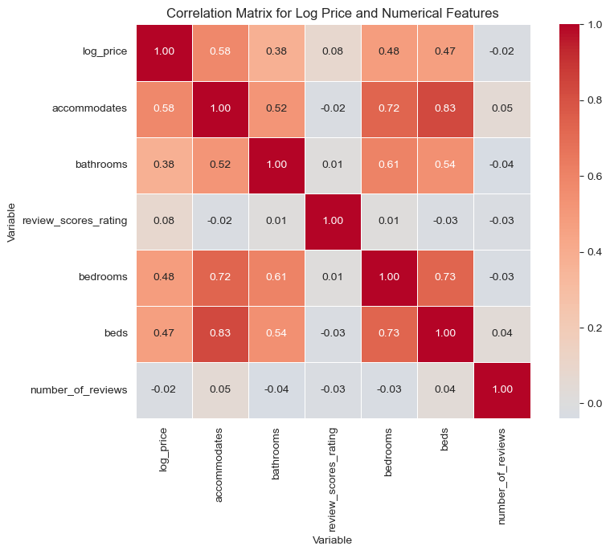

```python
plt.figure(figsize=(9, 7))

sns.heatmap(
    corr_matrix,
    annot=True,
    fmt=".2f",
    cmap="coolwarm",
    center=0,
    square=True,
    linewidths=0.5
)

plt.title(
    "Correlation Matrix for Log Price "
    "and Numerical Features"
)
plt.xlabel("Variable")
plt.ylabel("Variable")

plt.tight_layout()
plt.show()
```

```python
top_three = (
    corr_matrix["log_price"]
    .drop("log_price")
    .sort_values(
        key=abs,
        ascending=False
    )
    .head(3)
    .to_frame(
        "Correlation with log_price"
    )
)

display(
    top_three.round(4)
)
```

|  | Correlation with log_price |
| --- | --- |
| accommodates | 0.5781 |
| bedrooms | 0.4827 |
| beds | 0.4697 |

The three features most strongly correlated with log price were `accommodates` (0.5781), `bedrooms` (0.4827), and `beds` (0.4697). All three describe listing capacity, indicating that larger listings tend to have higher prices. However, these predictors also contained overlapping information. For example, the correlation between accommodates and beds was 0.8290, while bedrooms and beds had a correlation of 0.7298.

The positive correlation between accommodates and log price does not establish that increasing the stated accommodation capacity would cause the price to rise. Property size is a concrete confounding variable: larger properties can accommodate more guests and also command higher prices. City, neighbourhood and property type may create similar confounding relationships.

Because the dataset is observational and cross-sectional, the analysis can identify associations but cannot establish a causal effect. A causal conclusion would require stronger assumptions, additional control variables, or an appropriate causal identification design.

## Question 3 – Project Dataset Exploration (20 points)

Import the dataset you may use for your course project.

Deliver a short structured report containing:

- Shape, dtypes, missing values.
- Attribute type table: for every column, nominal / ordinal / interval / ratio and discrete / continuous.
- Choose **at most three** variables and explore their relationships with summary statistics and plots.
- Write a 150–200 word paragraph explaining what you learned and how it could inform later modeling.

**Note:** Different group members must use different variables if working in a group.

```python
project = pd.read_csv(
    "NIC_clean_dataset_v2.csv"
)

print(
    f"Rows: {project.shape[0]:,}"
)
print(
    f"Columns: {project.shape[1]}"
)

display(project.head())
display(
    project.dtypes.to_frame(
        "Pandas dtype"
    )
)
```

```
Rows: 10,000
Columns: 16
```

|  | student_id | age | programme_level | nationality_group | boarding_status | attendance_rate | assessment_completion_rate | current_grade | lms_engagement_score | wellbeing_flag | safeguarding_flag | intervention_count | guardian_contact_complete | record_completeness_score | access_review_overdue_flag | academic_risk_level |
| --- | --- | --- | --- | --- | --- | --- | --- | --- | --- | --- | --- | --- | --- | --- | --- | --- |
| 0 | STU000001 | 17 | A-Level | International | Boarding | 0.938 | 0.983 | 84.3 | 0.974 | False | False | 0 | True | 0.877 | False | Low |
| 1 | STU000002 | 17 | EAP | UK | Day | 0.873 | 0.647 | 72.2 | 0.627 | True | False | 1 | False | 0.722 | False | High |
| 2 | STU000003 | 17 | Foundation | UK | Homestay | 0.733 | 0.469 | 61.2 | 0.621 | True | False | 4 | True | 0.712 | True | High |
| 3 | STU000004 | 17 | A-Level | International | Day | 0.878 | 0.745 | 75.0 | 0.740 | False | False | 0 | True | 0.766 | True | Medium |
| 4 | STU000005 | 15 | GCSE | EU | Boarding | 0.981 | 0.953 | 83.5 | 0.904 | False | False | 0 | True | 0.792 | True | Low |

|  | Pandas dtype |
| --- | --- |
| student_id | object |
| age | int64 |
| programme_level | object |
| nationality_group | object |
| boarding_status | object |
| attendance_rate | float64 |
| assessment_completion_rate | float64 |
| current_grade | float64 |
| lms_engagement_score | float64 |
| wellbeing_flag | bool |
| safeguarding_flag | bool |
| intervention_count | int64 |
| guardian_contact_complete | bool |
| record_completeness_score | float64 |
| access_review_overdue_flag | bool |
| academic_risk_level | object |

```python
project.shape
```

```
(10000, 16)
```

```python
project_missing = pd.DataFrame({
    "Missing count":
        project.isna().sum(),

    "Missing percentage (%)":
        project.isna().mean() * 100
})

display(project_missing)
```

|  | Missing count | Missing percentage (%) |
| --- | --- | --- |
| student_id | 0 | 0.0 |
| age | 0 | 0.0 |
| programme_level | 0 | 0.0 |
| nationality_group | 0 | 0.0 |
| boarding_status | 0 | 0.0 |
| attendance_rate | 0 | 0.0 |
| assessment_completion_rate | 0 | 0.0 |
| current_grade | 0 | 0.0 |
| lms_engagement_score | 0 | 0.0 |
| wellbeing_flag | 0 | 0.0 |
| safeguarding_flag | 0 | 0.0 |
| intervention_count | 0 | 0.0 |
| guardian_contact_complete | 0 | 0.0 |
| record_completeness_score | 0 | 0.0 |
| access_review_overdue_flag | 0 | 0.0 |
| academic_risk_level | 0 | 0.0 |

The dataset contained 10,000 observations and 16 attributes. No missing values were identified in any column, so no deletion or imputation was required before the exploratory analysis.

```python
project_attribute_types = pd.DataFrame([
    [
        "student_id",
        "Nominal",
        "Discrete",
        "An anonymised identifier whose label has no magnitude."
    ],
    [
        "age",
        "Ratio",
        "Discrete",
        "Age is recorded in complete years and has a meaningful zero."
    ],
    [
        "programme_level",
        "Nominal",
        "Discrete",
        "Programme labels do not form one unambiguous common ranking."
    ],
    [
        "nationality_group",
        "Nominal",
        "Discrete",
        "Nationality groups are unordered categories."
    ],
    [
        "boarding_status",
        "Nominal",
        "Discrete",
        "Day, boarding and homestay are unordered categories."
    ],
    [
        "attendance_rate",
        "Ratio",
        "Continuous",
        "It is a proportion with a meaningful zero."
    ],
    [
        "assessment_completion_rate",
        "Ratio",
        "Continuous",
        "It is the proportion of assessments completed."
    ],
    [
        "current_grade",
        "Interval",
        "Continuous",
        "Grade differences are meaningful, but ratios do not represent proportional learning."
    ],
    [
        "lms_engagement_score",
        "Interval",
        "Continuous",
        "It is a composite engagement index."
    ],
    [
        "wellbeing_flag",
        "Nominal",
        "Discrete",
        "An asymmetric binary indicator of a wellbeing concern."
    ],
    [
        "safeguarding_flag",
        "Nominal",
        "Discrete",
        "An asymmetric binary indicator of a safeguarding concern."
    ],
    [
        "intervention_count",
        "Ratio",
        "Discrete",
        "It is a count with a meaningful zero."
    ],
    [
        "guardian_contact_complete",
        "Nominal",
        "Discrete",
        "An asymmetric binary completion indicator."
    ],
    [
        "record_completeness_score",
        "Ratio",
        "Continuous",
        "It is a proportion-like completeness measure."
    ],
    [
        "access_review_overdue_flag",
        "Nominal",
        "Discrete",
        "An asymmetric binary indicator of an overdue review."
    ],
    [
        "academic_risk_level",
        "Ordinal",
        "Discrete",
        "The categories follow the order Low, Medium and High."
    ]
], columns=[
    "Attribute",
    "Measurement scale",
    "Data nature",
    "Reason"
])

display(project_attribute_types)
```

|  | Attribute | Measurement scale | Data nature | Reason |
| --- | --- | --- | --- | --- |
| 0 | student_id | Nominal | Discrete | An anonymised identifier whose label has no magnitude. |
| 1 | age | Ratio | Discrete | Age is recorded in complete years and has a meaningful zero. |
| 2 | programme_level | Nominal | Discrete | Programme labels do not form one unambiguous common ranking. |
| 3 | nationality_group | Nominal | Discrete | Nationality groups are unordered categories. |
| 4 | boarding_status | Nominal | Discrete | Day, boarding and homestay are unordered categories. |
| 5 | attendance_rate | Ratio | Continuous | It is a proportion with a meaningful zero. |
| 6 | assessment_completion_rate | Ratio | Continuous | It is the proportion of assessments completed. |
| 7 | current_grade | Interval | Continuous | Grade differences are meaningful, but ratios do not represent proportional learning. |
| 8 | lms_engagement_score | Interval | Continuous | It is a composite engagement index. |
| 9 | wellbeing_flag | Nominal | Discrete | An asymmetric binary indicator of a wellbeing concern. |
| 10 | safeguarding_flag | Nominal | Discrete | An asymmetric binary indicator of a safeguarding concern. |
| 11 | intervention_count | Ratio | Discrete | It is a count with a meaningful zero. |
| 12 | guardian_contact_complete | Nominal | Discrete | An asymmetric binary completion indicator. |
| 13 | record_completeness_score | Ratio | Continuous | It is a proportion-like completeness measure. |
| 14 | access_review_overdue_flag | Nominal | Discrete | An asymmetric binary indicator of an overdue review. |
| 15 | academic_risk_level | Ordinal | Discrete | The categories follow the order Low, Medium and High. |

```python
project_vars = [
    "attendance_rate",
    "assessment_completion_rate",
    "current_grade"
]
```

```python
project_summary = (
    project[project_vars]
    .describe()
    .T
)

project_summary["skewness"] = (
    project[project_vars]
    .skew()
)

display(
    project_summary.round(4)
)
```

|  | count | mean | std | min | 25% | 50% | 75% | max | skewness |
| --- | --- | --- | --- | --- | --- | --- | --- | --- | --- |
| attendance_rate | 10000.0 | 0.8879 | 0.0703 | 0.584 | 0.841 | 0.890 | 0.941 | 1.0 | -0.3628 |
| assessment_completion_rate | 10000.0 | 0.7915 | 0.1048 | 0.400 | 0.719 | 0.794 | 0.867 | 1.0 | -0.1853 |
| current_grade | 10000.0 | 78.7502 | 9.4004 | 36.700 | 72.600 | 79.000 | 85.300 | 100.0 | -0.2120 |

```python
project_corr = (
    project[project_vars]
    .corr()
)

display(
    project_corr.round(4)
)
```

|  | attendance_rate | assessment_completion_rate | current_grade |
| --- | --- | --- | --- |
| attendance_rate | 1.0000 | 0.4508 | 0.4404 |
| assessment_completion_rate | 0.4508 | 1.0000 | 0.5931 |
| current_grade | 0.4404 | 0.5931 | 1.0000 |

```python
project_sample = project.sample(
    n=3000,
    random_state=42
)
```

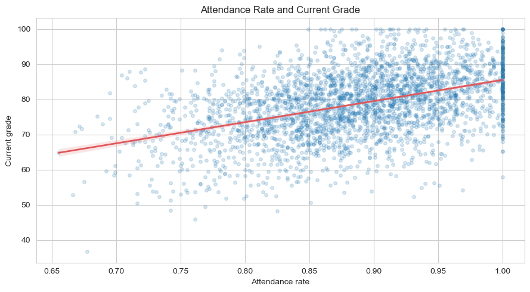

```python
plt.figure(figsize=(9, 5))

sns.regplot(
    data=project_sample,
    x="attendance_rate",
    y="current_grade",
    scatter_kws={
        "alpha": 0.18,
        "s": 16
    },
    line_kws={
        "color": "#E15759",
        "linewidth": 2
    }
)

plt.title(
    "Attendance Rate and Current Grade"
)
plt.xlabel("Attendance rate")
plt.ylabel("Current grade")

plt.tight_layout()
plt.show()
```

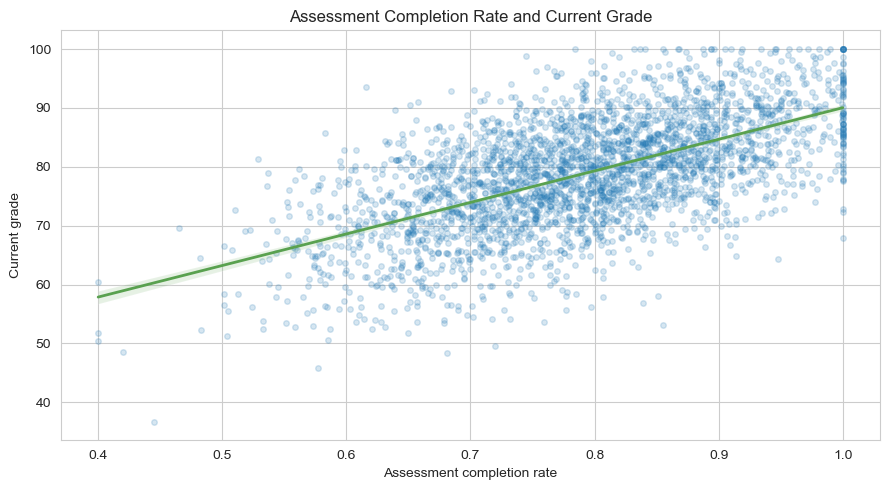

```python
plt.figure(figsize=(9, 5))

sns.regplot(
    data=project_sample,
    x="assessment_completion_rate",
    y="current_grade",
    scatter_kws={
        "alpha": 0.18,
        "s": 16
    },
    line_kws={
        "color": "#59A14F",
        "linewidth": 2
    }
)

plt.title(
    "Assessment Completion Rate and Current Grade"
)
plt.xlabel("Assessment completion rate")
plt.ylabel("Current grade")

plt.tight_layout()
plt.show()
```

The project dataset contains 10,000 complete student records, so no missing-value imputation is required. Current grade averaged 78.75 with a standard deviation of 9.40, while mean attendance and assessment-completion rates were 0.888 and 0.792. Both behaviours were positively related to achievement, but assessment completion had the stronger relationship: its correlation with current grade was 0.593, compared with 0.440 for attendance. Attendance and assessment completion were also moderately correlated at 0.451, suggesting overlapping engagement information.

For later modelling, current grade can be treated as a continuous target, with attendance and assessment completion as interpretable predictors. Their joint use may improve prediction, although multicollinearity should be checked. Nonlinear effects may also matter because improvement from very low to moderate engagement may differ from improvement near full engagement. These observational relationships are not necessarily causal: prior attainment, programme difficulty, wellbeing and access to support may influence both engagement and grades. A later model should therefore include appropriate controls, examine nonlinear terms, and be evaluated on a held-out test set or through cross-validation.

## Submission Checklist

- `ipynb` file with all cells executed.
- Exported `HTML` file.
- All plots have titles, axis labels, and interpretations.
- All code is reproducible.
- The submission is well-structured and easy to follow.